# Effects of sediment on the fertilization of coral gametes

Lillian J. Tuttle

9/25/2020

These datasets contain information from multiple articles (**Ref_name**) and studies/experiments (**Ref**) within those articles about the effects of SUSPENDED sediment on the **fertilization success** of coral gametes. I would like to explore the dose-response relationship between sediment ‘dose’ and the effect size, estimated here as the standardized mean difference between treatment and control, in terms of Hedges’ *d*:

- Hedges’ *d* is the standardized mean difference between the treatment and control groups (Hedges and Olkin 1985). Each study may have multiple Hedges’ *d* calculations, one for each treatment-control comparison at each time-point.
- ‘Dose’ can be quantified as sediment exposure concentration (mg/L), exposure duration (days), or as “cumulative exposure”, for which I multiply concentration and duration (mg x day/L).

Each study/experiment (Ref) may contain multiple sets of controls and treatments (due to using multiple species or sediment types, for instance). Thus, I have added two categorical vectors, ‘**Comparison**’ and ‘Control’, which group each set of control-treatment comparisons into a unique two-letter code, within which is one control (Control==“1”) and at least one treatment (Control==“0”). **Therefore, ‘Comparison’ is nested within ‘Ref’, which is further nested within ‘Ref_name’.**

# I. Fertilization success

## A. Suspended Sediment, Dataset WITH Outlier

### 1. Plots

I calculated the standardized mean difference in terms of Hedges’ *d* and plot it here with respect to exposure concentration. I did this first for a Hedges’ *d* that I calculated before importing the data to R and again for a Hedges’ *d* that is calculated by the dosresmeta::covar.smd function.

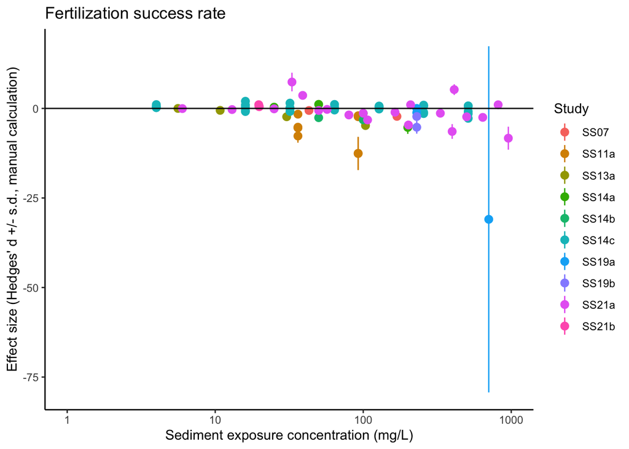

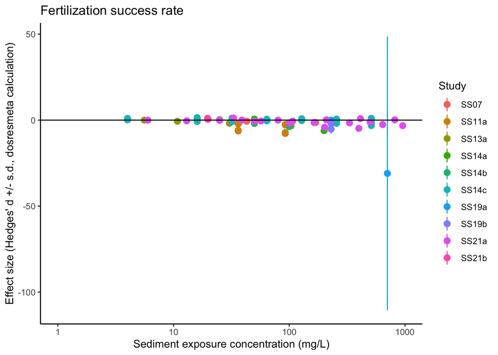

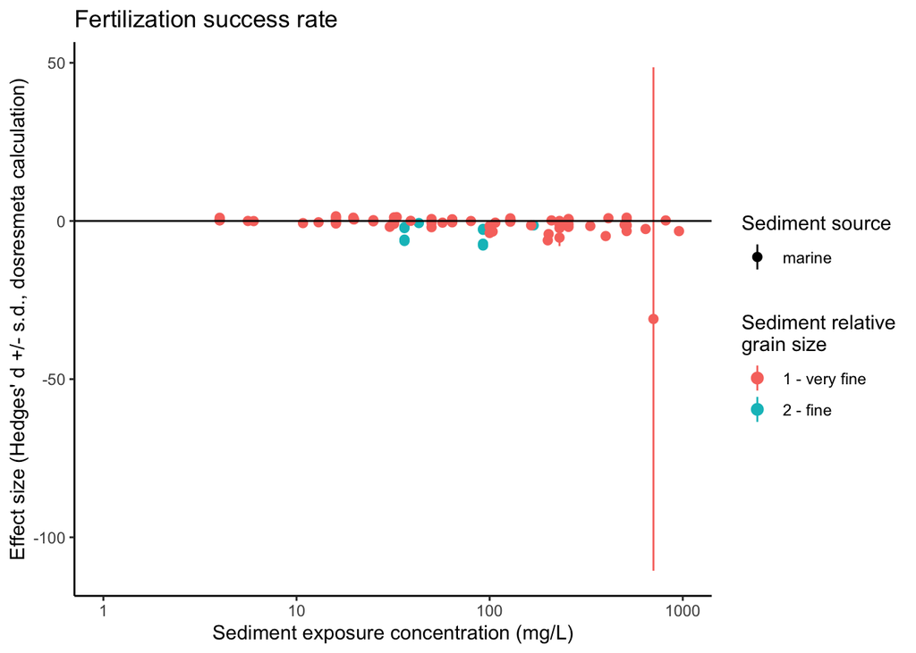

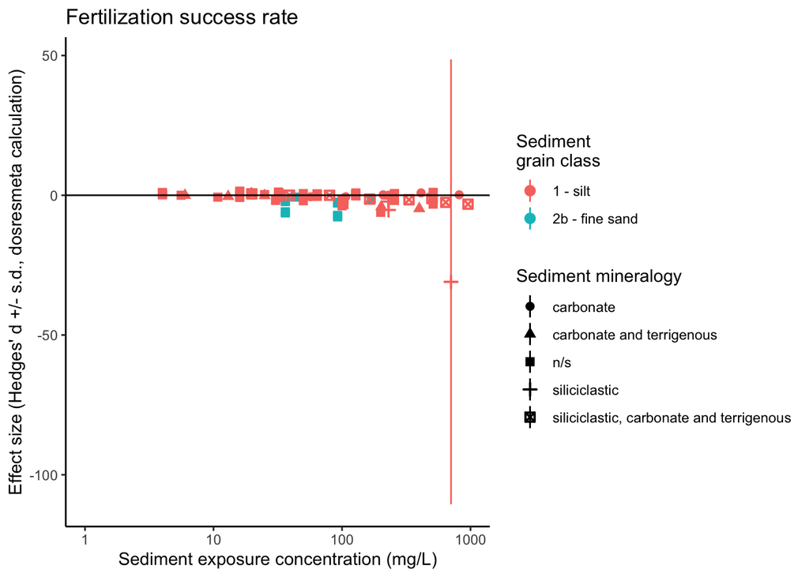

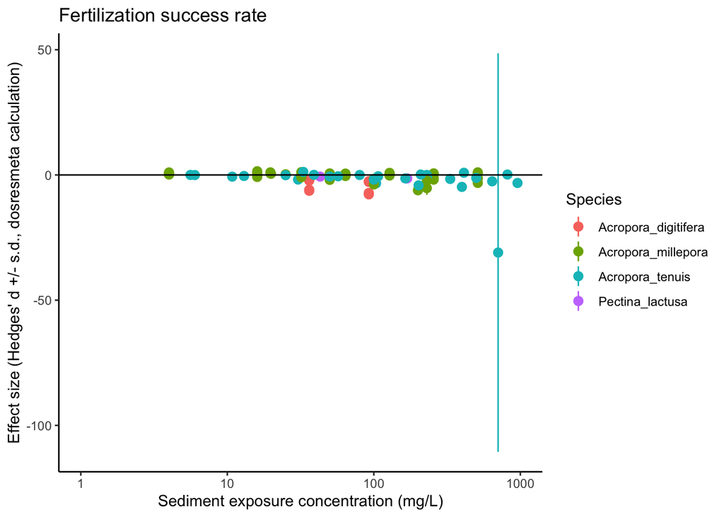

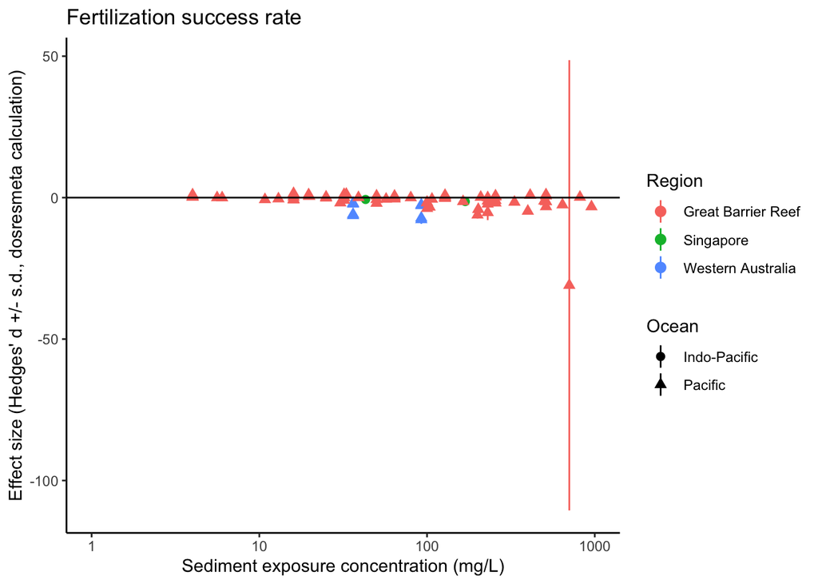

It is interesting that there is a difference between how I calculated Hedges’ *d* and how *dosresmeta* appears to calculate it. But in both cases, there may be a negative effect of sediment exposure on effect size, perhaps especially for *Acropora digitifera*. Any effect of geography (ocean and region) may be obscured or co-linear with phylogeny. I still need to investigate the effects of sediment type (source, origin, grain size). I also conduct analyses both with and without the outlier.

### 2. Model Fitting

The following set of functions model fixed and random (nested) effects WITHOUT accounting for within-comparison (or within-study) correlations. The output for each is a univariate, random-effects meta-regression.

To account for within-comparison correlations in the mixmeta model, I replace the ‘S’ argument with a ‘control’ argument, which requires me to provide the covariance matrices, as done with the covar.smd function.

And now to compare relative fit of linear models…

```
##                  df      AIC
## mod_SS_fertil_1c  3 361.0351
## mod_SS_fertil_2c  4 354.6355
## mod_SS_fertil_3c  4 356.0578
## mod_SS_fertil_4c  5 356.6355
## mod_SS_fertil_5c  3 387.2032
## mod_SS_fertil_6c  4 377.3209
## mod_SS_fertil_7c  4 379.6802
## mod_SS_fertil_1d  5 285.5248
## mod_SS_fertil_2d  8 279.6127
## mod_SS_fertil_3d  8 282.9116
## mod_SS_fertil_4d 11 284.9893
## mod_SS_fertil_5d  5 284.3237
## mod_SS_fertil_6d  8 272.7914
## mod_SS_fertil_7d  8 279.5600
```

And now to evaluate residuals of models…

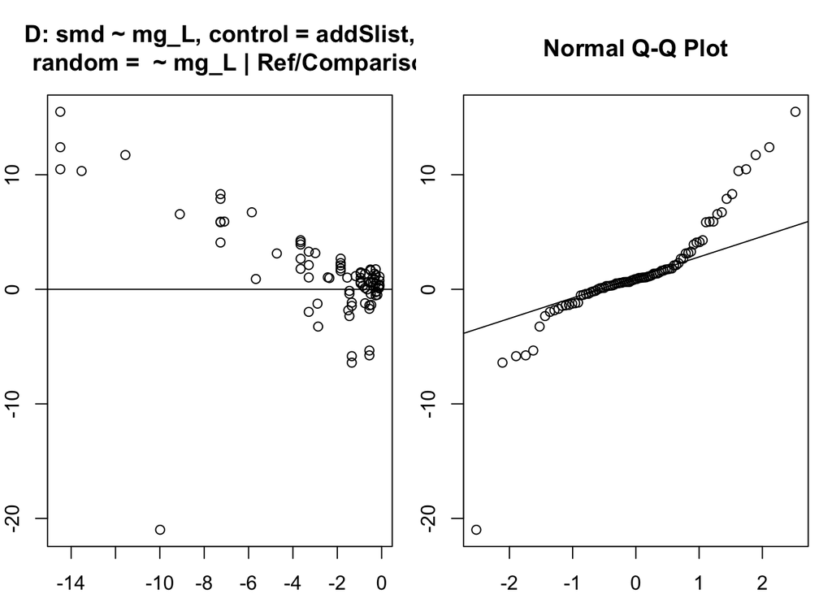

Patterns: 1. There could be non-linearities that need to be accounted for. 2. Very strong outlier in negative residual land! 3. First let’s try a log transformation of sediment exposure before adding non-linear models.

Now let’s check out a log, base 10 transformation of sediment exposure to see if it improves the residuals of the models.

To account for within-comparison correlations in the mixmeta model, I replace the ‘S’ argument with a ‘control’ argument, which requires me to provide the covariance matrices, as done with the covar.smd function.

### 3. Model Comparison and Summary

And now to compare relative fit of logarithmic models…

```
##                      df      AIC
## log_mod_SS_fertil_1c  3 340.5332
## log_mod_SS_fertil_2c  4 335.3569
## log_mod_SS_fertil_3c  4 336.2453
## log_mod_SS_fertil_4c  5 337.3569
## log_mod_SS_fertil_5c  3 364.8470
## log_mod_SS_fertil_6c  4 356.5798
## log_mod_SS_fertil_7c  4 358.1585
## log_mod_SS_fertil_1d  5 293.6684
## log_mod_SS_fertil_2d  8 292.7423
## log_mod_SS_fertil_3d  8 291.4942
## log_mod_SS_fertil_4d 11 297.4942
## log_mod_SS_fertil_5d  5 298.2159
## log_mod_SS_fertil_6d  8 294.5329
## log_mod_SS_fertil_7d  8 293.2683
```

And now to evaluate residuals of models…

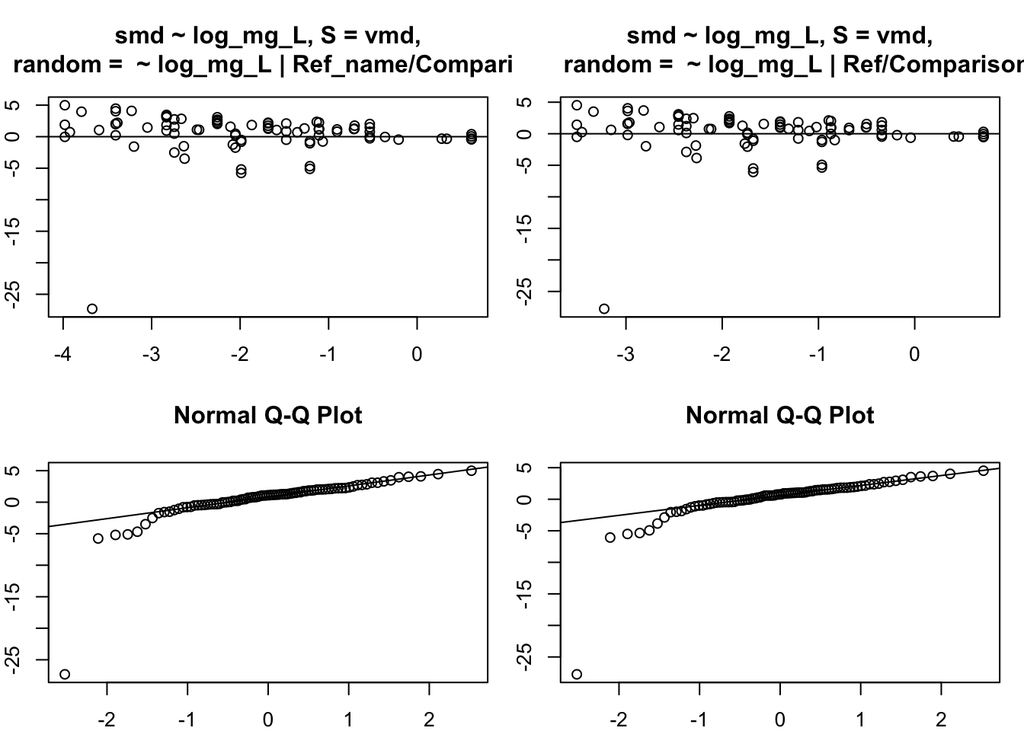

Patterns: 1. Residuals for all models are very similar. 2. Looking MUCH better, with less extreme residuals, with exception of one very strong outlier in negative residual land! 3. Let’s check out non-linear options to see if it helps with outlier. Otherwise, will need to analyze with and without this data-point.

These are much improved from the non-logged models! There is still one outlier, so I will need to analyze the data with and without it. Out of curiosity, I will also fit non-linear models to the data, to see if there is any improvement…

```
##    Min. 1st Qu.  Median    Mean 3rd Qu.    Max.
##  0.6021  1.5051  1.9657  1.8956  2.3617  3.0103
```

```
##                          df      AIC
## log_mod_SS_fertil_NL3d   24 295.0986
## log_mod_SS_fertil_NL3d_2 10 287.2616
## log_mod_SS_fertil_NL2d   24 295.9052
## log_mod_SS_fertil_NL2d_2 10 287.7545
```

And now to evaluate residuals of non-linear models…

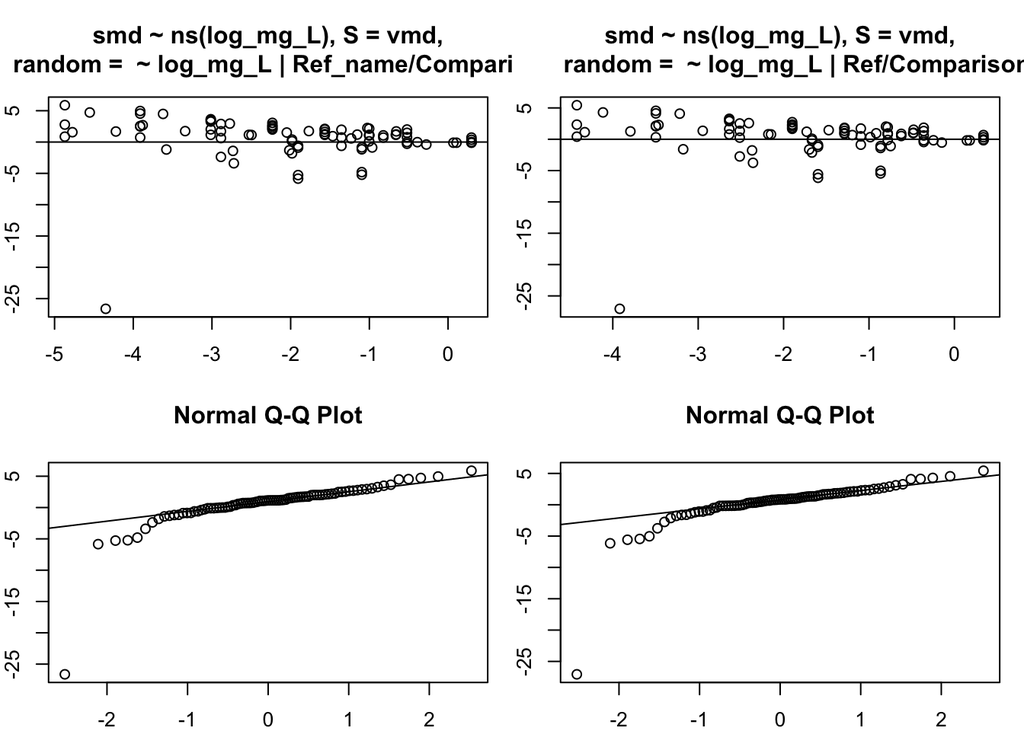

Patterns: 1. No obvious changes/improvements in residuals from linear versions. 2. Still strong outlier in negative residual land! Let’s check out models without outlier.

The residuals for the non-linear, logarithmic models are very similar to the analogous linear, logarithmic models. I will defer to the linear models because they are simpler.

### 4. Best-Fit Model Summary

#### i. Exposure concentration is PREDICTOR

Now I will predict the effect size along the exposure range and plot with confidence intervals.

```
## Call:  mixmeta(formula = smd ~ log10(Sed_level_standardized), S = vmd,
##     data = ES_SS_fertilization2, random = ~log10(Sed_level_standardized) |
##         Ref_name/Comparison, method = "ml")
##
## Univariate extended random-effects meta-regression
## Dimension: 1
## Estimation method: ML
##
## Fixed-effects coefficients
##                                Estimate  Std. Error        z  Pr(>|z|)
## (Intercept)                      1.7626      0.4004   4.4023    0.0000
## log10(Sed_level_standardized)   -1.9079      0.4625  -4.1254    0.0000
##                                95%ci.lb  95%ci.ub
## (Intercept)                      0.9779    2.5473  ***
## log10(Sed_level_standardized)   -2.8144   -1.0015  ***
## ---
## Signif. codes:  0 '***' 0.001 '**' 0.01 '*' 0.05 '.' 0.1 ' ' 1
##
## Random-effects (co)variance components
##  Formula: ~log10(Sed_level_standardized) | Ref_name
##  Structure: General positive-definite
##                                Std. Dev         Corr
## (Intercept)                      0.0002  (Intercept)
## log10(Sed_level_standardized)    0.7541            1
##
##  Formula: ~log10(Sed_level_standardized) | Comparison
##  Structure: General positive-definite
##                                Std. Dev         Corr
## (Intercept)                      1.1130  (Intercept)
## log10(Sed_level_standardized)    1.3000      -0.9556
##
## Univariate Cochran Q-test for residual heterogeneity:
## Q = 475.2947 (df = 84), p-value = 0.0000
## I-square statistic = 82.3%
##
## 86 units, 1 outcome, 86 observations, 2 fixed and 6 random-effects parameters
##    logLik        AIC        BIC
## -137.7471   291.4942   311.1290
```

```
## Univariate Cochran Q-test for residual heterogeneity
## Q = 475.29 (df = 84), p-value = 0.00
```

```
##                       df      AIC
## log_mod_SS_fertil_3d   8 291.4942
## log_mod_SS_fertil_3d2 11 287.6823
```

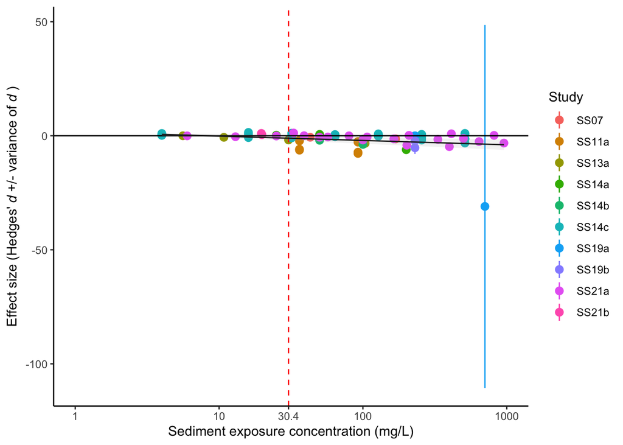

## B. Suspended Sediment, WITHOUT outlier

### 1. Plots

I calculated the standardized mean difference in terms of Hedges’ *d* and plot it here with respect to exposureconcentration. I did this first for a Hedges’ *d* that I calculated before importing the data to R and again for a Hedges’ *d* that is calculated by the dosresmeta::covar.smd function.

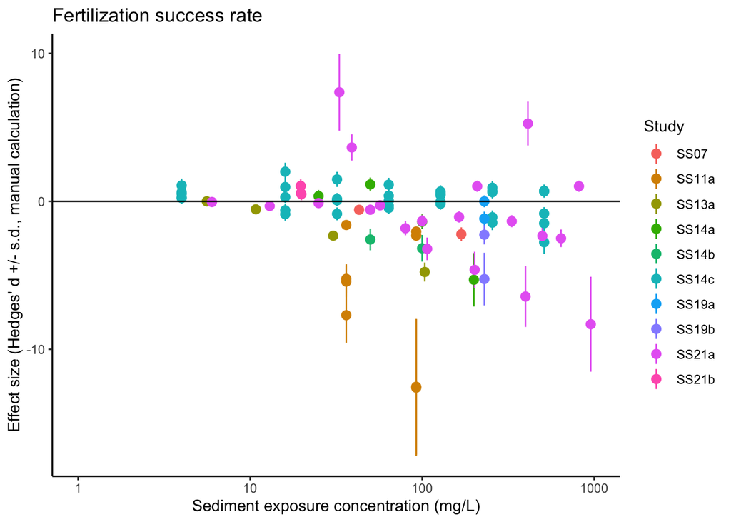

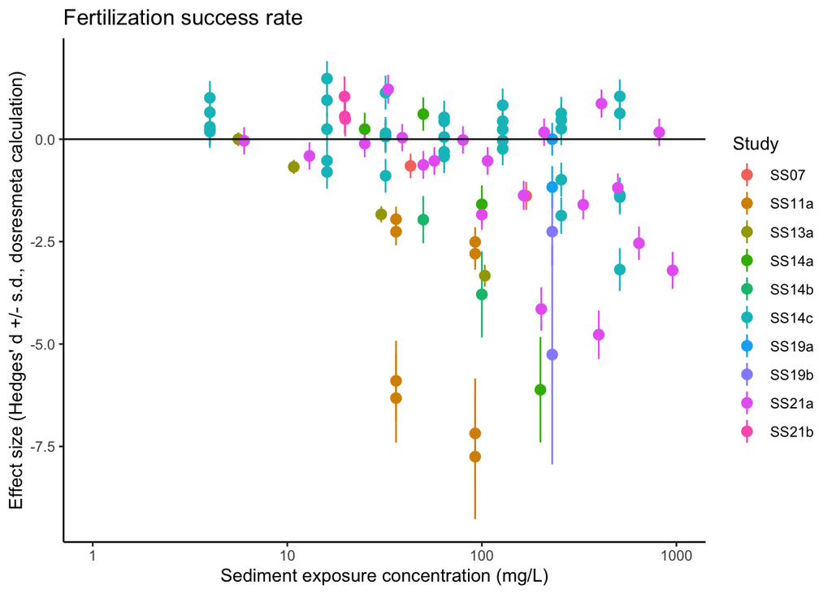

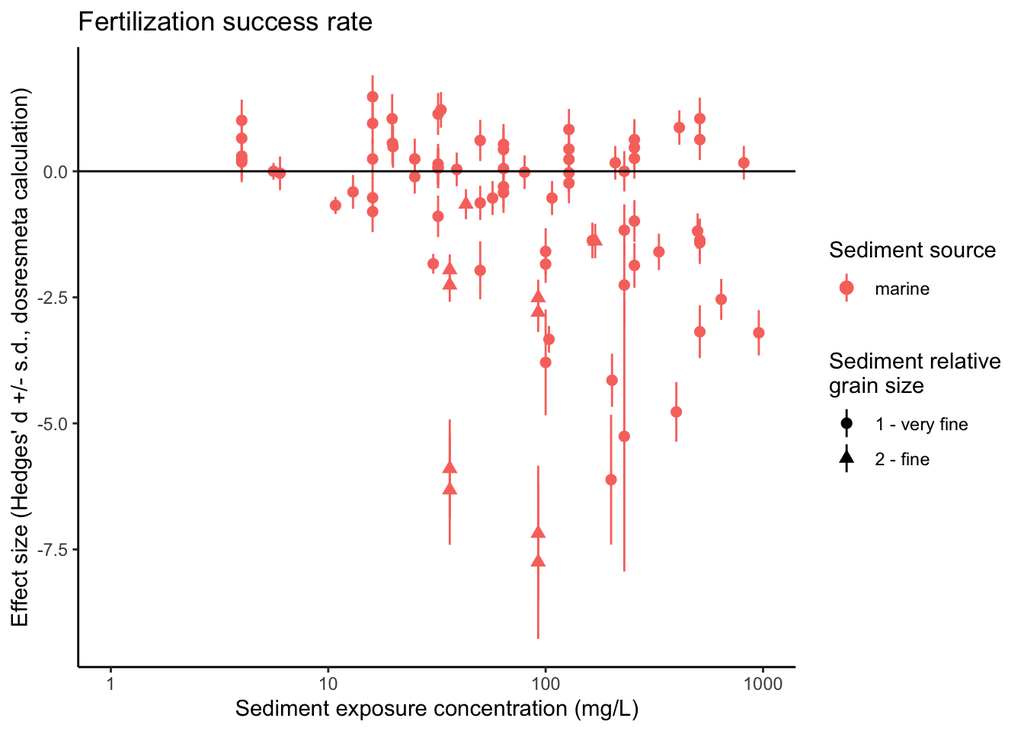

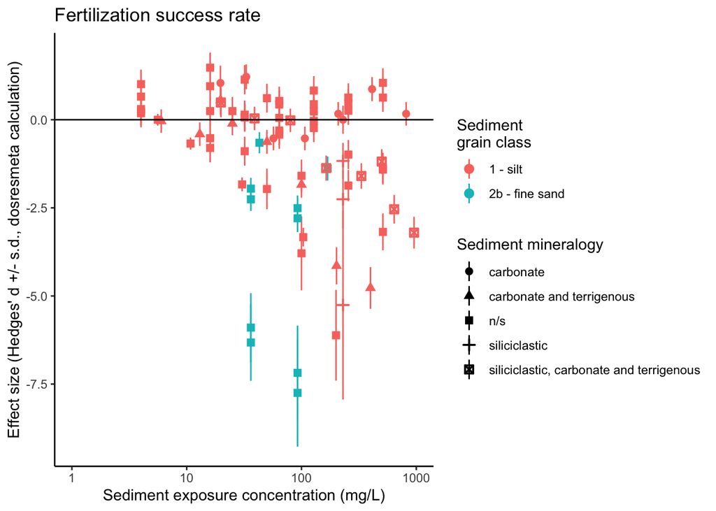

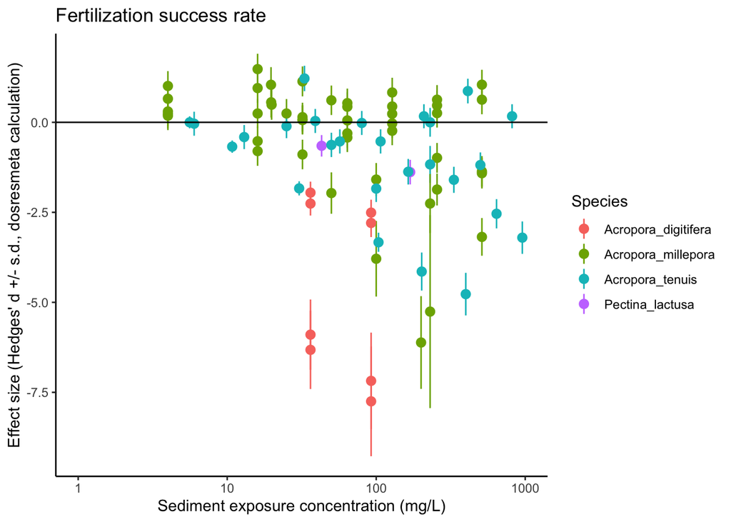

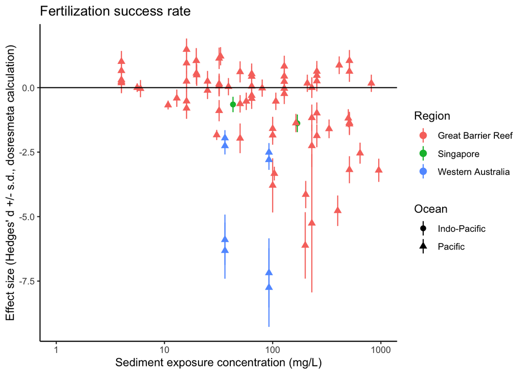

It is interesting that there is a difference between how I calculated Hedges’ *d* and how *dosresmeta* appears to calculate it. But in both cases, there may be a negative effect of sediment exposure on effect size, perhaps especially for *Acropora digitifera*. Any effect of geography (ocean and region) may be obscured or co-linear with phylogeny (or vice versa). I still need to investigate the effects of sediment type (source, origin, grain size).

### 2. Model Fitting

The following set of functions model fixed and random (nested) effects WITHOUT accounting for within-comparison (or within-study) correlations. The output for each is a univariate, random-effects meta-regression.

To account for within-comparison correlations in the mixmeta model, I replace the ‘S’ argument with a ‘control’ argument, which requires me to provide the covariance matrices, as done with the covar.smd function.

And now to compare relative fit of linear models…

```
##                    df      AIC
## mod_SS_fertil_b_1c  3 345.1773
## mod_SS_fertil_b_2c  4 338.1096
## mod_SS_fertil_b_3c  4 340.1276
## mod_SS_fertil_b_4c  5 340.1096
## mod_SS_fertil_b_5c  3 370.8175
## mod_SS_fertil_b_6c  4 360.3285
## mod_SS_fertil_b_7c  4 363.2766
## mod_SS_fertil_b_1d  5 275.9350
## mod_SS_fertil_b_2d  8 271.1960
## mod_SS_fertil_b_3d  8 272.3538
## mod_SS_fertil_b_4d 11 273.2662
## mod_SS_fertil_b_5d  5 273.2754
## mod_SS_fertil_b_6d  8 259.5317
## mod_SS_fertil_b_7d  8 267.9876
```

And now to evaluate residuals of models…

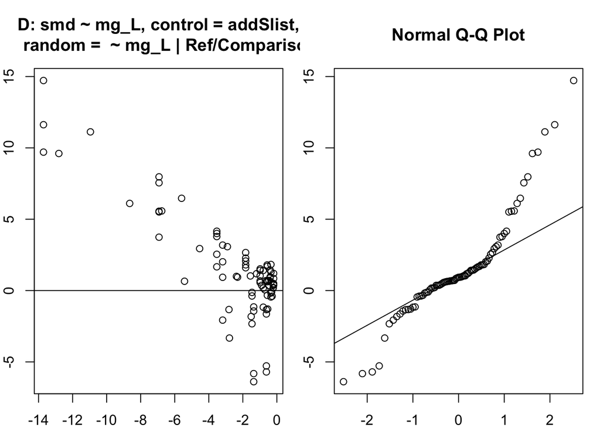

Patterns: 1. There could be non-linearities that need to be accounted for? 2. First let’s check out a log-transformation of sediment exposure to see if that improves residuals…

Now let’s try log transformation of the sediment predictor. I will use the base 10 logarithmic scale because it seems suitable for the spread of sediment exposure in all cases.

To account for within-comparison correlations in the mixmeta model, I replace the ‘S’ argument with a ‘control’ argument, which requires me to provide the covariance matrices, as done with the covar.smd function.

### 3. Model Comparison and Summary

And now to compare relative fit of log-linear models…

```
##                        df      AIC
## log_mod_SS_fertil_b_1c  3 324.4709
## log_mod_SS_fertil_b_2c  4 318.5085
## log_mod_SS_fertil_b_3c  4 319.9426
## log_mod_SS_fertil_b_4c  5 320.5085
## log_mod_SS_fertil_b_5c  3 348.3286
## log_mod_SS_fertil_b_6c  4 339.3327
## log_mod_SS_fertil_b_7c  4 341.4724
## log_mod_SS_fertil_b_1d  5 279.0223
## log_mod_SS_fertil_b_2d  8 276.6970
## log_mod_SS_fertil_b_3d  8 276.1839
## log_mod_SS_fertil_b_4d 11 282.0314
## log_mod_SS_fertil_b_5d  5 282.8449
## log_mod_SS_fertil_b_6d  8 278.0228
## log_mod_SS_fertil_b_7d  8 277.4423
```

And now to evaluate residuals of models…

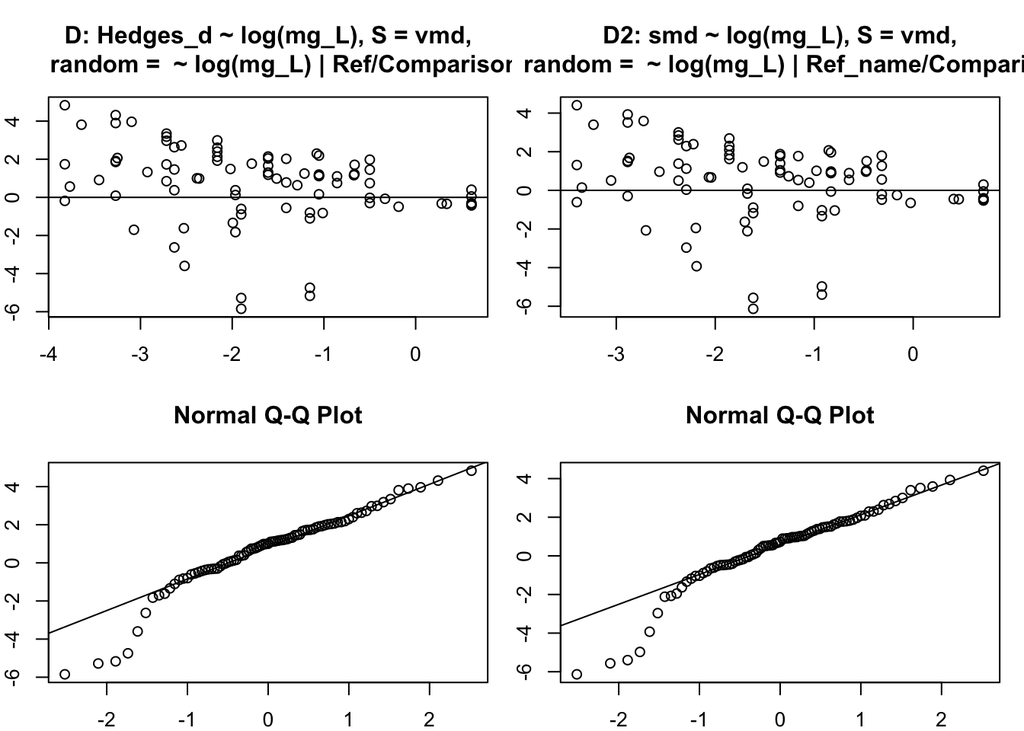

Patterns: 1. Residuals for best-fit models are very similar. 2. Looks waaaaay better! Magnitude of residuals down and spread much more “acceptable”. 3. Q-Q plots still looking “meh” on low end of x-axis – but no obvious reason to fit non-linear models.

### 4. Best-Fit Model Summary

#### i. Exposure concentration is PREDICTOR

Now I will predict the effect size along the exposure range and plot with confidence intervals.

```
## Call:  mixmeta(formula = smd ~ log10(Sed_level_standardized), S = vmd,
##     data = ES_SS_fertilization_b2, random = ~log10(Sed_level_standardized) |
##         Ref_name/Comparison, method = "ml")
##
## Univariate extended random-effects meta-regression
## Dimension: 1
## Estimation method: ML
##
## Fixed-effects coefficients
##                                Estimate  Std. Error        z  Pr(>|z|)
## (Intercept)                      1.7167      0.3903   4.3988    0.0000
## log10(Sed_level_standardized)   -1.8409      0.4517  -4.0753    0.0000
##                                95%ci.lb  95%ci.ub
## (Intercept)                      0.9518    2.4816  ***
## log10(Sed_level_standardized)   -2.7262   -0.9555  ***
## ---
## Signif. codes:  0 '***' 0.001 '**' 0.01 '*' 0.05 '.' 0.1 ' ' 1
##
## Random-effects (co)variance components
##  Formula: ~log10(Sed_level_standardized) | Ref_name
##  Structure: General positive-definite
##                                Std. Dev         Corr
## (Intercept)                      0.0253  (Intercept)
## log10(Sed_level_standardized)    0.7471            1
##
##  Formula: ~log10(Sed_level_standardized) | Comparison
##  Structure: General positive-definite
##                                Std. Dev         Corr
## (Intercept)                      1.0539  (Intercept)
## log10(Sed_level_standardized)    1.2390      -0.9503
##
## Univariate Cochran Q-test for residual heterogeneity:
## Q = 464.3296 (df = 83), p-value = 0.0000
## I-square statistic = 82.1%
##
## 85 units, 1 outcome, 85 observations, 2 fixed and 6 random-effects parameters
##    logLik        AIC        BIC
## -130.0919   276.1839   295.7251
```

```
##                         df      AIC
## log_mod_SS_fertil_b_3d   8 276.1839
## log_mod_SS_fertil_b_3d2 11 271.9301
```

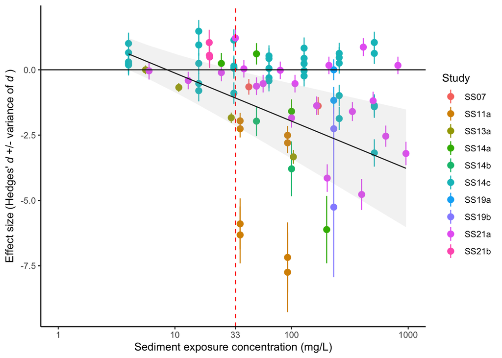

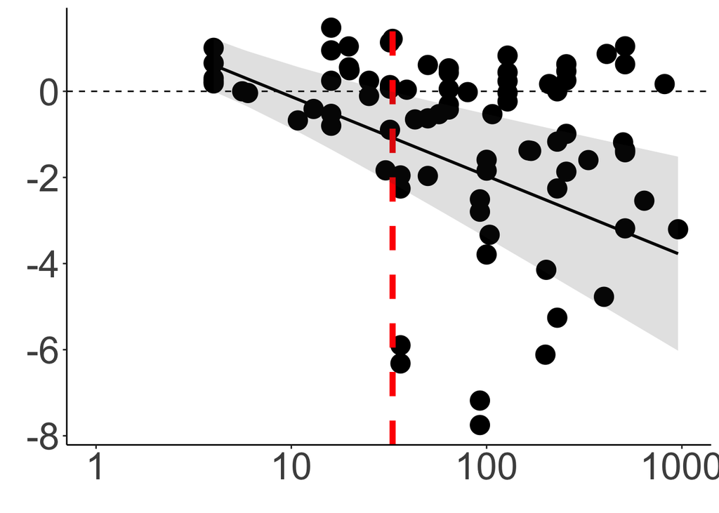